# Rep_data_project3

Taoyuan Yang

2021/1/17

## Introduction

This project is the Reproducible research course project 2 on the coursea online learning website.Storms and other severe weather events can cause both public health and economic problems for communities and municipalities. Many severe events can result in fatalities, injuries, and property damage, and preventing such outcomes to the extent possible is a key concern.

This project involves exploring the U.S. National Oceanic and Atmospheric Administration’s (NOAA) storm database. This database tracks characteristics of major storms and weather events in the United States, including when and where they occur, as well as estimates of any fatalities, injuries, and property damage.

## Loading libraries and data

```r
library(ggplot2)
library(plyr)
library(dplyr)
storm.data <- read.csv(bzfile("repdata_data_StormData.csv.bz2"),header = TRUE)
```

## Data Processing

### Extracting variables of required variable for health and economy impact analysis

```r
vars <- c( "EVTYPE", "FATALITIES", "INJURIES", "PROPDMG", "PROPDMGEXP", "CROPDMG", "CROPDMGEXP")
mydata <- storm.data[, vars]
```

```r
sort(table(mydata$EVTYPE), decreasing = TRUE)[1:10]
```

```
##
##          TSTM WIND               HAIL                               TORNADO
##             189928             180954              99497              49289
##        FLASH FLOOD THUNDERSTORM WINDS          LIGHTNING              FLOOD
##              27451              20843               9953               9586
##         HEAVY SNOW          HIGH WIND
##               8472               7432
```

### Grounping events

```r
# create a new variable EVENT to transform variable EVTYPE in groups
mydata$EVENT <- "OTHER"
# group by keyword in EVTYPE
mydata$EVENT[grep("HAIL", mydata$EVTYPE, ignore.case = TRUE)] <- "HAIL"
mydata$EVENT[grep("HEAT", mydata$EVTYPE, ignore.case = TRUE)] <- "HEAT"
mydata$EVENT[grep("FLOOD", mydata$EVTYPE, ignore.case = TRUE)] <- "FLOOD"
mydata$EVENT[grep("WIND", mydata$EVTYPE, ignore.case = TRUE)] <- "WIND"
mydata$EVENT[grep("STORM", mydata$EVTYPE, ignore.case = TRUE)] <- "STORM"
mydata$EVENT[grep("SNOW", mydata$EVTYPE, ignore.case = TRUE)] <- "SNOW"
mydata$EVENT[grep("TORNADO", mydata$EVTYPE, ignore.case = TRUE)] <- "TORNADO"
mydata$EVENT[grep("WINTER", mydata$EVTYPE, ignore.case = TRUE)] <- "WINTER"
mydata$EVENT[grep("RAIN", mydata$EVTYPE, ignore.case = TRUE)] <- "RAIN"
# listing the transformed event types
sort(table(mydata$EVENT), decreasing = TRUE)
```

```
##
##    WIND    HAIL   OTHER TORNADO   FLOOD   STORM    SNOW    RAIN  WINTER    HEAT
##  207856  183170  146384   52131   41469   33098   11750    9588    5363    1479
```

```r
mydata$PROPDMGEXP <- as.character(mydata$PROPDMGEXP)
mydata$PROPDMGEXP[is.na(mydata$PROPDMGEXP)] <- 0 # NA's considered as dollars
mydata$PROPDMGEXP[!grepl("K|M|B", mydata$PROPDMGEXP, ignore.case = TRUE)] <- 0 # everything exept K,M,B is dollar
```

###Transform to damage and dollar unit.

```r
mydata$PROPDMGEXP[grep("K", mydata$PROPDMGEXP, ignore.case = TRUE)] <- "3"
mydata$PROPDMGEXP[grep("M", mydata$PROPDMGEXP, ignore.case = TRUE)] <- "6"
mydata$PROPDMGEXP[grep("B", mydata$PROPDMGEXP, ignore.case = TRUE)] <- "9"
mydata$PROPDMGEXP <- as.numeric(as.character(mydata$PROPDMGEXP))
mydata$PROPDMG <- as.numeric(as.character(mydata$PROPDMG))
mydata$property.damage <- mydata$PROPDMG * 10^mydata$PROPDMGEXP

mydata$CROPDMGEXP <- as.character(mydata$CROPDMGEXP)
mydata$CROPDMGEXP[is.na(mydata$CROPDMGEXP)] <- 0 # NA's considered as dollars
mydata$CROPDMGEXP[!grepl("K|M|B", mydata$CROPDMGEXP, ignore.case = TRUE)] <- 0 # everything exept K,M,B is dollar
mydata$CROPDMGEXP[grep("K", mydata$CROPDMGEXP, ignore.case = TRUE)] <- "3"
mydata$CROPDMGEXP[grep("M", mydata$CROPDMGEXP, ignore.case = TRUE)] <- "6"
mydata$CROPDMGEXP[grep("B", mydata$CROPDMGEXP, ignore.case = TRUE)] <- "9"
mydata$CROPDMGEXP <- as.numeric(as.character(mydata$CROPDMGEXP))
mydata$CROPDMG <- as.numeric(as.character(mydata$CROPDMG))
mydata$crop.damage <- mydata$CROPDMG * 10^mydata$CROPDMGEXP
```

```r
sort(table(mydata$property.damage), decreasing = TRUE)[1:10]
```

```
##
##      0   5000  25000  10000  50000   2000   1000 250000   2500   3000
## 410414  18804  12346  10938   8788   8260   7228   7188   5420   5013
```

```r
sort(table(mydata$crop.damage), decreasing = TRUE)[1:10]
```

```
##
##      0   5000  10000  50000   2000  1e+05    500   1000  25000  20000
## 533167   2845   1335   1335    691    630    563    531    514    500
```

## Analysis

### Population health impact

```r
# aggregate FATALITIES and INJURIES by type of EVENT
agg.fatalites.and.injuries <- ddply(mydata, .(EVENT), summarize, Total = sum(as.numeric(FATALITIES) + as.numeric(INJURIES),  na.rm = TRUE))
agg.fatalites.and.injuries$type <- "fatalities and injuries"

# aggregate FATALITIES by type of EVENT
agg.fatalities <- ddply(mydata, .(EVENT), summarize, Total = sum(as.numeric(FATALITIES), na.rm = TRUE))
agg.fatalities$type <- "fatalities"

# aggregate INJURIES by type of EVENT
agg.injuries <- ddply(mydata, .(EVENT), summarize, Total = sum(as.numeric(INJURIES), na.rm = TRUE))
agg.injuries$type <- "injuries"

# combine all
agg.health <- rbind(agg.fatalities, agg.injuries)

health.by.event <- join (agg.fatalities, agg.injuries, by="EVENT", type="inner")
health.by.event
```

```
##      EVENT Total       type Total     type
## 1    FLOOD  5685 fatalities 10644 injuries
## 2     HAIL  4702 fatalities  3174 injuries
## 3     HEAT  2422 fatalities  5847 injuries
## 4    OTHER 49009 fatalities 55925 injuries
## 5     RAIN 12262 fatalities 12624 injuries
## 6     SNOW  6231 fatalities  5042 injuries
## 7    STORM 35065 fatalities 20012 injuries
## 8  TORNADO 12728 fatalities 86177 injuries
## 9     WIND  3214 fatalities 12788 injuries
## 10  WINTER   234 fatalities  1443 injuries
```

### Economic impact

```r
# aggregate PropDamage and CropDamage by type of EVENT
agg.propdmg.and.cropdmg <- ddply(mydata, .(EVENT), summarize, Total = sum(as.numeric(property.damage) + as.numeric(crop.damage),  na.rm = TRUE))
agg.propdmg.and.cropdmg$type <- "property and crop damage"

# aggregate PropDamage by type of EVENT
agg.prop <- ddply(mydata, .(EVENT), summarize, Total = sum(as.numeric(property.damage), na.rm = TRUE))
agg.prop$type <- "property"

# aggregate INJURIES by type of EVENT
agg.crop <- ddply(mydata, .(EVENT), summarize, Total = sum(as.numeric(crop.damage), na.rm = TRUE))
agg.crop$type <- "crop"

# combine all
agg.economic <- rbind(agg.prop, agg.crop)


economic.by.event <- join (agg.prop, agg.crop, by="EVENT", type="inner")
economic.by.event
```

```
##      EVENT        Total     type        Total type
## 1    FLOOD 2.692241e+10 property 2.018328e+12 crop
## 2     HAIL 2.017632e+12 property 1.966673e+09 crop
## 3     HEAT 1.440255e+07 property 4.118928e+08 crop
## 4    OTHER 6.558046e+10 property 3.232504e+10 crop
## 5     RAIN 1.089015e+10 property 6.640214e+09 crop
## 6     SNOW 2.884465e+09 property 1.645781e+08 crop
## 7    STORM 4.675457e+10 property 2.027671e+12 crop
## 8  TORNADO 4.264168e+10 property 4.378601e+09 crop
## 9     WIND 1.251357e+10 property 5.292649e+09 crop
## 10  WINTER 7.555311e+09 property 3.192800e+07 crop
```

##Result

### Health Impact

The figure shows the top event with the highest total fatalities and injuries.

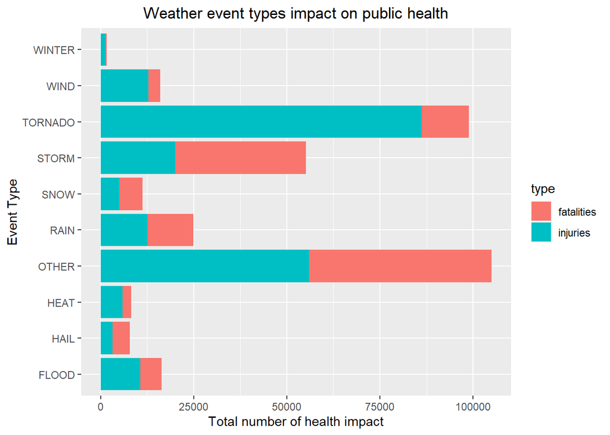

```r
# transform EVENT to factor variable for health variables
agg.health$EVENT <- as.factor(agg.health$EVENT)

# plot FATALITIES and INJURIES by EVENT
health.plot <- ggplot(agg.health, aes(x = EVENT, y = Total, fill = type)) + geom_bar(stat = "identity") +
  coord_flip() +
  xlab("Event Type") +
  ylab("Total number of health impact") +
  ggtitle("Weather event types impact on public health") +
  theme(plot.title = element_text(hjust = 0.5))
print(health.plot)
```

### Economic Impact

The figure shows the top 10 events in highest total economic damages(Property and Crop)

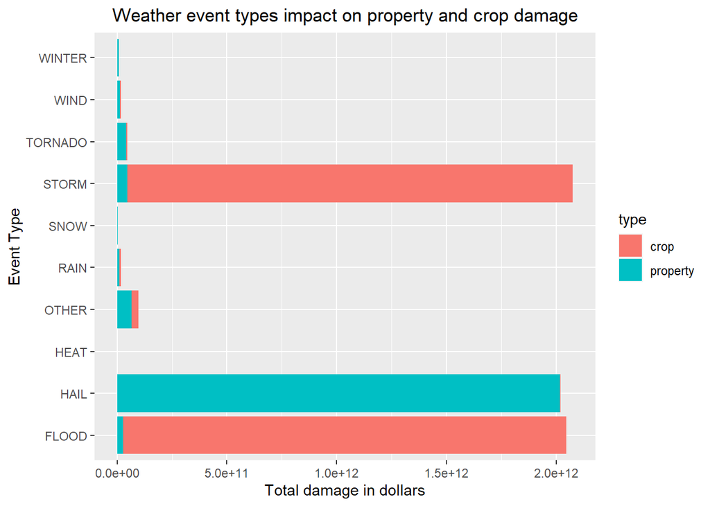

```r
# # transform EVENT to factor variable for economic variables
agg.economic$EVENT <- as.factor(agg.economic$EVENT)

# plot PROPERTY damage and CROP damage by EVENT
economic.plot <- ggplot(agg.economic, aes(x = EVENT, y = Total, fill = type)) + geom_bar(stat = "identity") +
  coord_flip() +
  xlab("Event Type") +
  ylab("Total damage in dollars") +
  ggtitle("Weather event types impact on property and crop damage") +
  theme(plot.title = element_text(hjust = 0.5))
print(economic.plot)
```